# Wheatfall_Stage4

```python
#Foundations
import pandas as pd
import numpy as np
import re
import os

!pip install plotnine

from plotnine import *
import warnings
warnings.filterwarnings('ignore')

# see all columns
pd.set_option('display.max_columns', None)
import matplotlib.pyplot as plt
```

```python
# Install necessary packages
import pandas as pd
import numpy as np
!pip install xgboost


# Preprocessing packages
from sklearn.preprocessing import LabelEncoder
from sklearn.decomposition import PCA
from imblearn.over_sampling import SMOTE
from sklearn.preprocessing import StandardScaler
from collections import Counter
from sklearn.svm import SVC
from sklearn.metrics import classification_report, accuracy_score, roc_auc_score, confusion_matrix


from sklearn.ensemble import RandomForestClassifier
from sklearn.neighbors import KNeighborsClassifier
from sklearn.model_selection import train_test_split, GridSearchCV
from sklearn.tree import DecisionTreeClassifier
from sklearn.linear_model import LogisticRegression
from sklearn.metrics import accuracy_score, classification_report, confusion_matrix, r2_score, mean_squared_error
from xgboost import XGBClassifier
from sklearn.model_selection import cross_val_score
from sklearn.metrics import roc_curve, roc_auc_score
from sklearn.model_selection import RandomizedSearchCV


import matplotlib.pyplot as plt
import seaborn as sns
```

### Civil Right Data Collection

https://civilrightsdata.ed.gov/data

- CRDC 2017-18 is a cross-sectional survey that collects data on key education and civil rights issues in the nation's public schools, which include student enrollment and educational programs and services, disaggregated by race/ethnicity, sex, limited English proficiency, and disability. LEAs submit administrative records about schools in the district. CRDC 2017-18 is a universe survey.
- Codebook and Definitions: https://civilrightsdata.ed.gov/assets/downloads/2021-2220List20Definitions.pdf

## Characterizing the Data

1. Create main dataset with all features necessary (all features are other .csv files, concat by school ID)

```python
# Creating a base dataset of all alternative schools, alt schools focus,
# school id, state, COMBOKEY so I can match with other feature datasets
school = pd.read_csv(
    "/Users/joyamelvin/Desktop/Data_Science_II/Last_Girls_Standing_Repo/2017-18_CRDC_data/2017-18 Public-Use Files/Data/SCH/CRDC/CSV/School Characteristics.csv",
    encoding='windows-1252'
)
```

```python
school.SCH_UGDETAIL_ES.unique()
```

```
array(['-9', 'No', 'Yes'], dtype=object)
```

```python
school.SCH_STATUS_ALT.unique()
```

```
array(['No', 'Yes'], dtype=object)
```

```python
school.SCH_ALTFOCUS.unique()
```

```
array(['-9', 'Both', 'Discipline', 'Academic'], dtype=object)
```

```python
school.info()
```

```
<class 'pandas.core.frame.DataFrame'>
RangeIndex: 97632 entries, 0 to 97631
Data columns (total 32 columns):
 #   Column              Non-Null Count  Dtype
---  ------              --------------  -----
 0   LEA_STATE           97632 non-null  object
 1   LEA_STATE_NAME      97632 non-null  object
 2   LEAID               97632 non-null  object
 3   LEA_NAME            97632 non-null  object
 4   SCHID               97632 non-null  int64
 5   SCH_NAME            97632 non-null  object
 6   COMBOKEY            97632 non-null  object
 7   JJ                  97632 non-null  object
 8   SCH_GRADE_PS        97632 non-null  object
 9   SCH_GRADE_KG        97632 non-null  object
```

[output cut: 24 more lines]

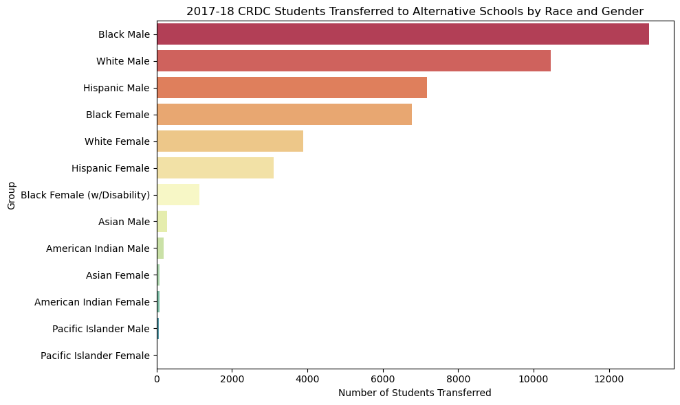

```python
# Preliminary EDA: Seeing Demographic difference in all students transferred to Alternative Schools by Discipline

# Transfers

transfers_df = pd.read_csv(
     "/Users/joyamelvin/Desktop/Data_Science_II/Last_Girls_Standing_Repo/2017-18_CRDC_data/2017-18 Public-Use Files/Data/SCH/CRDC/CSV/Transfers.csv",
    encoding='windows-1252'
)

transfer_vars = [
'SCH_DISCWODIS_TFRALT_BL_F',
'SCH_DISCWDIS_TFRALT_IDEA_BL_F',
'SCH_DISCWODIS_TFRALT_HI_M',
'SCH_DISCWODIS_TFRALT_HI_F',
'SCH_DISCWODIS_TFRALT_AM_M',
'SCH_DISCWODIS_TFRALT_AM_F',
'SCH_DISCWODIS_TFRALT_AS_M',
'SCH_DISCWODIS_TFRALT_AS_F',
'SCH_DISCWODIS_TFRALT_HP_M',
'SCH_DISCWODIS_TFRALT_HP_F',
'SCH_DISCWODIS_TFRALT_BL_M',
'SCH_DISCWODIS_TFRALT_BL_F',
'SCH_DISCWODIS_TFRALT_WH_M',
'SCH_DISCWODIS_TFRALT_WH_F'
]

reserve_codes = [-3, -5, -6, -8, -9, -11]

# Validate which transfer_vars exist in the DataFrame
existing_transfer_vars = [col for col in transfer_vars if col in transfers_df.columns]

# Replace reserve codes with 0 one column at a time
for col in existing_transfer_vars:
    transfers_df[col] = pd.to_numeric(transfers_df[col], errors='coerce')  # ensure numeric
    transfers_df[col] = transfers_df[col].replace(reserve_codes, 0)

# Sum totals across all schools
transfer_totals = transfers_df[existing_transfer_vars].sum().sort_values(ascending=False)

# Prepare for plotting
transfer_df = transfer_totals.reset_index()
transfer_df.columns = ['Group', 'Total Transferred']

transfer_df['Group'] = transfer_df['Group'].str.replace('SCH_DISCWODIS_TFRALT_', '').str.replace('_', ' ')

# Labels
label_map = {
    'BL M': 'Black Male',
    'BL F': 'Black Female',
    'WH M': 'White Male',
    'WH F': 'White Female',
    'HI M': 'Hispanic Male',
    'HI F': 'Hispanic Female',
    'AM M': 'American Indian Male',
    'AM F': 'American Indian Female',
    'AS M': 'Asian Male',
    'AS F': 'Asian Female',
    'HP M': 'Pacific Islander Male',
    'HP F': 'Pacific Islander Female',
    'SCH DISCWDIS TFRALT IDEA BL F': 'Black Female (w/Disability)'
}

# Apply label mapping
transfer_df['Group'] = transfer_df['Group'].replace(label_map)


# Plot
plt.figure(figsize=(10, 6))
sns.barplot(data=transfer_df, x='Total Transferred', y='Group', palette='Spectral')
plt.title('2017-18 CRDC Students Transferred to Alternative Schools by Race and Gender')
plt.xlabel('Number of Students Transferred')
plt.tight_layout()
plt.savefig("intro_eda.png", dpi=300)
plt.show()
```

```python
# Selecting only the columns of interest
needed_columns = ['LEA_STATE', 'LEAID', 'SCH_ALTFOCUS', 'SCH_STATUS_ALT', 'SCHID', 'SCH_NAME', 'COMBOKEY']
school_subset = school[needed_columns]

#filtering for all alt schools
school_filtered = school_subset[school_subset['SCH_STATUS_ALT'] == 'Yes']
school_filtered.info()

# Save the filtered subset to a new CSV file if needed
# school_filtered.to_csv('school_filtered_subset.csv', index=False)
```

```
<class 'pandas.core.frame.DataFrame'>
Index: 3343 entries, 85 to 96530
Data columns (total 7 columns):
 #   Column          Non-Null Count  Dtype
---  ------          --------------  -----
 0   LEA_STATE       3343 non-null   object
 1   LEAID           3343 non-null   object
 2   SCH_ALTFOCUS    3343 non-null   object
 3   SCH_STATUS_ALT  3343 non-null   object
 4   SCHID           3343 non-null   int64
 5   SCH_NAME        3343 non-null   object
 6   COMBOKEY        3343 non-null   object
dtypes: int64(1), object(6)
memory usage: 208.9+ KB
```

```python
school_filtered.info()
```

```
<class 'pandas.core.frame.DataFrame'>
Index: 3343 entries, 85 to 96530
Data columns (total 7 columns):
 #   Column          Non-Null Count  Dtype
---  ------          --------------  -----
 0   LEA_STATE       3343 non-null   object
 1   LEAID           3343 non-null   object
 2   SCH_ALTFOCUS    3343 non-null   object
 3   SCH_STATUS_ALT  3343 non-null   object
 4   SCHID           3343 non-null   int64
 5   SCH_NAME        3343 non-null   object
 6   COMBOKEY        3343 non-null   object
dtypes: int64(1), object(6)
memory usage: 208.9+ KB
```

```python
school_filtered.SCH_ALTFOCUS.describe()
```

```
count     3343
unique       3
top       Both
freq      1647
Name: SCH_ALTFOCUS, dtype: object
```

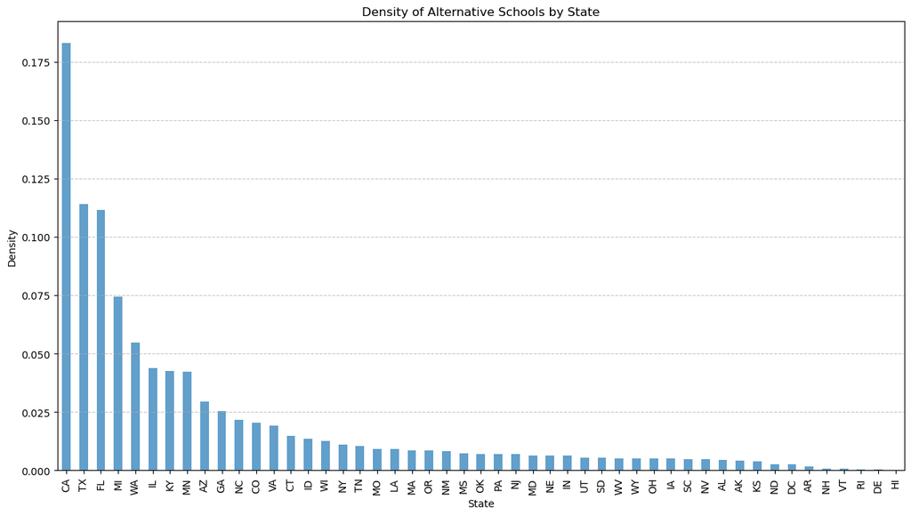

```python
# Density of Alt Schools per State
plt.figure(figsize=(15, 8))
school_filtered['LEA_STATE'].value_counts(normalize=True).plot(kind='bar', alpha=0.7)
plt.xlabel('State')
plt.ylabel('Density')
plt.title('Density of Alternative Schools by State')
plt.grid(axis='y', linestyle='--', alpha=0.7)
plt.show()
```

```python
school_filtered.info()
```

```
<class 'pandas.core.frame.DataFrame'>
Index: 3343 entries, 85 to 96530
Data columns (total 7 columns):
 #   Column          Non-Null Count  Dtype
---  ------          --------------  -----
 0   LEA_STATE       3343 non-null   object
 1   LEAID           3343 non-null   object
 2   SCH_ALTFOCUS    3343 non-null   object
 3   SCH_STATUS_ALT  3343 non-null   object
 4   SCHID           3343 non-null   int64
 5   SCH_NAME        3343 non-null   object
 6   COMBOKEY        3343 non-null   object
dtypes: int64(1), object(6)
memory usage: 208.9+ KB
```

```python
#Alt-Schools counts per state
school_filtered.LEA_STATE.value_counts()
```

```
LEA_STATE
CA    612
TX    381
FL    373
MI    249
WA    183
IL    147
KY    142
MN    141
AZ     99
GA     85
NC     72
CO     68
VA     64
CT     50
ID     45
WI     42
NY     37
TN     35
MO     31
LA     31
MA     29
OR     29
NM     28
MS     25
OK     23
PA     23
NJ     23
MD     21
NE     21
IN     21
UT     18
SD     18
WV     17
WY     17
OH     17
IA     17
SC     16
NV     16
AL     15
AK     14
KS     13
ND      9
DC      9
AR      6
NH      3
VT      3
RI      2
DE      2
HI      1
Name: count, dtype: int64
```

```python
#collect all COMBOKEY from this df and put into a list
alt_school_id_list = school_filtered['COMBOKEY'].tolist()
```

## I. Retrieving Target Variables: Negative Implications of Alt. Schooling

```python
school_filtered.info()
```

```
<class 'pandas.core.frame.DataFrame'>
Index: 3343 entries, 85 to 96530
Data columns (total 7 columns):
 #   Column          Non-Null Count  Dtype
---  ------          --------------  -----
 0   LEA_STATE       3343 non-null   object
 1   LEAID           3343 non-null   object
 2   SCH_ALTFOCUS    3343 non-null   object
 3   SCH_STATUS_ALT  3343 non-null   object
 4   SCHID           3343 non-null   int64
 5   SCH_NAME        3343 non-null   object
 6   COMBOKEY        3343 non-null   object
dtypes: int64(1), object(6)
memory usage: 208.9+ KB
```

```python
#If a school serves both students with academic difficulties and students with discipline problems = Both
#.
school_filtered.SCH_ALTFOCUS.unique()
```

```
array(['Both', 'Discipline', 'Academic'], dtype=object)
```

```python
# Checking school-funding variable (not included in 2020-2021 data)
money = pd.read_csv("/Users/joyamelvin/Desktop/Data_Science_II/Last_Girls_Standing_Repo/2017-18_CRDC_data/2017-18 Public-Use Files/Data/SCH/CRDC/CSV/School Expenditures.csv",
                       encoding='windows-1252'
)
```

```python
money.head()
```

|  | LEA_STATE | LEA_STATE_NAME | LEAID | LEA_NAME | SCHID | SCH_NAME | COMBOKEY | JJ | SCH_SAL_TOTPERS_WOFED | SCH_FTE_TEACH_WOFED | SCH_SAL_TEACH_WOFED | SCH_NPE_WOFED | SCH_FTE_AID_WOFED | SCH_SAL_AID_WOFED | SCH_FTE_SUP_WOFED | SCH_SAL_SUP_WOFED | SCH_FTE_ADM_WOFED | SCH_SAL_ADM_WOFED | SCH_SAL_TEACH_WFED | SCH_FTE_AID_WFED | SCH_SAL_AID_WFED | SCH_FTE_SUP_WFED | SCH_SAL_SUP_WFED | SCH_FTE_ADM_WFED | SCH_SAL_ADM_WFED | SCH_SAL_TOTPERS_WFED | SCH_NPE_WFED |
| --- | --- | --- | --- | --- | --- | --- | --- | --- | --- | --- | --- | --- | --- | --- | --- | --- | --- | --- | --- | --- | --- | --- | --- | --- | --- | --- | --- |
| 0 | AL | ALABAMA | 0100002 | Alabama Youth Services | 1705 | Wallace Sch - Mt Meigs Campus | 010000201705 | Yes | 1908676.0 | 25.00 | 1827143.00 | 102500.00 | 0.0 | -9.0 | 0.00 | -9.00 | 1.0 | 81533.0 | 1827143.00 | 0.0 | 0.0 | 0.00 | 0.00 | 1.0 | 81533.0 | 1908676.00 | 102500.00 |
| 1 | AL | ALABAMA | 0100002 | Alabama Youth Services | 1706 | McNeel Sch - Vacca Campus | 010000201706 | Yes | 1563570.0 | 16.00 | 1305463.00 | 30502.00 | 0.0 | -9.0 | 0.00 | -9.00 | 1.0 | 82000.0 | 1223463.00 | 0.0 | 0.0 | 0.00 | 0.00 | 0.0 | 82000.0 | 1305463.00 | 0.00 |
| 2 | AL | ALABAMA | 0100002 | Alabama Youth Services | 1876 | Alabama Youth Services | 010000201876 | No | 3998276.0 | 60.00 | 3400850.00 | 341426.00 | 0.0 | -9.0 | 0.00 | -9.00 | 1.0 | 81533.0 | 3400850.00 | 0.0 | 0.0 | 0.00 | 0.00 | 1.0 | 81533.0 | 5122976.00 | 0.00 |
| 3 | AL | ALABAMA | 0100002 | Alabama Youth Services | 99995 | AUTAUGA CAMPUS | 010000299995 | Yes | 305220.0 | 3.00 | 305220.00 | 18700.00 | 0.0 | -9.0 | 0.00 | -9.00 | 1.0 | 81553.0 | 305220.00 | 0.0 | 0.0 | 0.00 | 0.00 | 1.0 | 82000.0 | 386551.00 | 18700.00 |
| 4 | AL | ALABAMA | 0100005 | Albertville City | 870 | Albertville Middle School | 010000500870 | No | 2394774.5 | 38.29 | 1782926.22 | 566767.07 | 2.0 | 44432.0 | 7.29 | 309952.28 | 3.0 | 257464.0 | 1944222.84 | 3.0 | 66178.0 | 13.89 | 514793.08 | 3.0 | 257464.0 | 2782657.92 | 1059055.88 |

```python
# Getting BL_F variables
school_dict = pd.read_csv(
    "/Users/joyamelvin/Desktop/Data_Science_II/Last_Girls_Standing_Repo/2017-18_CRDC_data/2017-18 Public-Use Files/Documentation/2017-18 CRDC File StructureSingle.csv",
    encoding='latin1',
    on_bad_lines='skip'
)
```

```python
school_dict.head()
```

|  | Column Finder | Field Name | Field Description | Unnamed: 3 | Unnamed: 4 |
| --- | --- | --- | --- | --- | --- |
| 0 | A | LEA_STATE | State Abbreviation | NaN | NaN |
| 1 | B | LEA_STATE_NAME | State Name | NaN | NaN |
| 2 | C | LEAID | 7 Digit LEAID District Identification Code | NaN | NaN |
| 3 | D | LEA_NAME | District Name | NaN | NaN |
| 4 | E | LEA_ADDRESS | District Address | NaN | NaN |

```python
bf_variable_list = school_dict[
    school_dict['Field Description'].str.contains('Black Female', case=False, na=False)
]['Field Name'].tolist()
```

```python
bf_variable_list
```

```
['LEA_HSEPART_BL_F',
 'LEA_DISTEDENR_BL_F',
 'SCH_MATHENR_ADVM_BL_F',
 'SCH_APENR_BL_F',
 'SCH_APMATHENR_BL_F',
 'SCH_APSCIENR_BL_F',
 'SCH_APOTHENR_BL_F',
 'SCH_APEXAM_ONEORMORE_BL_F',
 'SCH_APEXAM_NONE_BL_F',
 'SCH_ALGENR_G08_BL_F',
 'SCH_ALGENR_GS0910_BL_F',
 'SCH_ALGENR_GS1112_BL_F',
 'SCH_ALGPASS_G08_BL_F',
 'SCH_ALGPASS_GS0910_BL_F',
 'SCH_ALGPASS_GS1112_BL_F',
 'SCH_MATHENR_ALG2_BL_F',
 'SCH_SCIENR_BIOL_BL_F',
 'SCH_MATHENR_CALC_BL_F',
 'SCH_SCIENR_CHEM_BL_F',
 'SCH_PSDISC_CORP_BL_F',
 'SCH_DISCWODIS_CORP_BL_F',
 'SCH_DISCWDIS_CORP_IDEA_BL_F',
 'SCH_DUALENR_BL_F',
 'SCH_PSENR_BL_F',
 'SCH_ENR_BL_F',
 'SCH_LEPENR_BL_F',
 'SCH_LEPPROGENR_BL_F',
 'SCH_IDEAENR_BL_F',
 'SCH_504ENR_BL_F',
 'SCH_PSDISC_EXP_BL_F',
 'SCH_DISCWODIS_EXPWE_BL_F',
 'SCH_DISCWODIS_EXPWOE_BL_F',
 'SCH_DISCWODIS_EXPZT_BL_F',
 'SCH_DISCWDIS_EXPWE_IDEA_BL_F',
 'SCH_DISCWDIS_EXPWOE_IDEA_BL_F',
 'SCH_DISCWDIS_EXPZT_IDEA_BL_F',
 'SCH_MATHENR_GEOM_BL_F',
 'SCH_GTENR_BL_F',
 'SCH_HBREPORTED_SEX_BL_F',
 'SCH_HBREPORTED_RAC_BL_F',
```

[output cut: 20 more lines]

```
 'SCH_RET_G10_BL_F',
 'SCH_RET_G11_BL_F',
 'SCH_RET_G12_BL_F',
 'SCH_SATACT_BL_F',
 'SCH_PSDISC_SINGOOS_BL_F',
 'SCH_PSDISC_MULTOOS_BL_F',
 'SCH_DISCWODIS_ISS_BL_F',
 'SCH_DISCWODIS_SINGOOS_BL_F',
 'SCH_DISCWODIS_MULTOOS_BL_F',
 'SCH_DISCWDIS_ISS_IDEA_BL_F',
 'SCH_DISCWDIS_SINGOOS_IDEA_BL_F',
 'SCH_DISCWDIS_MULTOOS_IDEA_BL_F',
 'SCH_DAYSMISSED_BL_F',
 'SCH_DISCWODIS_TFRALT_BL_F',
 'SCH_DISCWDIS_TFRALT_IDEA_BL_F']
```

### 1. Retention (K-12)

```python
# Define your retention variables
retention_vars = [
    'SCH_RET_G06_BL_F', 'SCH_RET_G07_BL_F', 'SCH_RET_G08_BL_F',
    'SCH_RET_G09_BL_F', 'SCH_RET_G10_BL_F', 'SCH_RET_G11_BL_F',
    'SCH_RET_G12_BL_F',
    'TOT_RET_G06_M',
    'TOT_RET_G06_F',
    'TOT_RET_G07_M',
    'TOT_RET_G07_F',
    'TOT_RET_G08_M',
    'TOT_RET_G08_F',
    'TOT_RET_G09_M',
    'TOT_RET_G09_F',
    'TOT_RET_G10_M',
    'TOT_RET_G10_F',
    'TOT_RET_G11_M',
    'TOT_RET_G11_F',
    'TOT_RET_G12_M',
    'TOT_RET_G12_F',
    'COMBOKEY'  # Add COMBOKEY so we can merge
]

# Load just the columns you need
retention_df = pd.read_csv(
    "/Users/joyamelvin/Desktop/Data_Science_II/Last_Girls_Standing_Repo/2017-18_CRDC_data/2017-18 Public-Use Files/Data/SCH/CRDC/CSV/Retention.csv",
    usecols=retention_vars,
    encoding='latin1'  # safer encoding
)

# Merge with your filtered school data
#merged_retention = pd.merge(
    #school_filtered,
    #retention_df,
    #on='COMBOKEY',
   # how='left'
#)
```

### 2. BF Population

- Overrall BL_F Students Enrolled
- Disabled (Under IDEA) BL_F Students enrolled
- Disabled (Under 504) BL_F Students enrolled

```python
enrollment_vars = [
'SCH_ENR_BL_F',
'SCH_IDEAENR_BL_F',
'SCH_504ENR_BL_F',
'TOT_ENR_M',
'TOT_ENR_F',
'COMBOKEY'
]

enrollment_df = pd.read_csv("/Users/joyamelvin/Desktop/Data_Science_II/Last_Girls_Standing_Repo/2017-18_CRDC_data/2017-18 Public-Use Files/Data/SCH/CRDC/CSV/Enrollment.csv",
    usecols=enrollment_vars,
    encoding='latin1'  # safer encoding
)
```

### 3. Harm Variables

- Corporal Punishment -
- Expulsion -
- Harassment and Bullying -
- Referrals and Arrests -
- Restraint and Seclusion -
- Suspensions -
- *Not Added* Transfers
- Added: Retention -

```python
# Corporal Punishment
corporal_vars = [
 'SCH_DISCWODIS_CORP_BL_F',
 'SCH_DISCWDIS_CORP_IDEA_BL_F', 'COMBOKEY'
]

# Load just the columns you need
corporal_df = pd.read_csv(
    "/Users/joyamelvin/Desktop/Data_Science_II/Last_Girls_Standing_Repo/2017-18_CRDC_data/2017-18 Public-Use Files/Data/SCH/CRDC/CSV/Corporal Punishment.csv",
    usecols=corporal_vars,
    encoding='latin1'  # safer encoding
)

# Expulsion
expulsions_vars = [
 'SCH_DISCWODIS_EXPWE_BL_F',
 'SCH_DISCWODIS_EXPWOE_BL_F',
 'SCH_DISCWODIS_EXPZT_BL_F',
 'SCH_DISCWDIS_EXPWE_IDEA_BL_F',
 'SCH_DISCWDIS_EXPWOE_IDEA_BL_F',
 'SCH_DISCWDIS_EXPZT_IDEA_BL_F',
 'TOT_DISCWODIS_EXPWE_M',
 'TOT_DISCWODIS_EXPWE_F',
 'TOT_DISCWODIS_EXPWOE_M',
 'TOT_DISCWODIS_EXPWOE_F',
 'TOT_DISCWODIS_EXPZT_M',
 'TOT_DISCWODIS_EXPZT_F',
 'TOT_DISCWDIS_EXPWE_IDEA_M', 'TOT_DISCWDIS_EXPWE_IDEA_F',
 'TOT_DISCWDIS_EXPWOE_IDEA_M', 'TOT_DISCWDIS_EXPWOE_IDEA_F',
 'TOT_DISCWDIS_EXPZT_IDEA_M', 'TOT_DISCWDIS_EXPZT_IDEA_F', 'COMBOKEY'
]

# Load just the columns you need
expulsion_df = pd.read_csv(
    "/Users/joyamelvin/Desktop/Data_Science_II/Last_Girls_Standing_Repo/2017-18_CRDC_data/2017-18 Public-Use Files/Data/SCH/CRDC/CSV/Expulsions.csv",
    usecols=expulsions_vars,
    encoding='latin1'  # safer encoding
)

# Harassment and Bullying
hb_vars = [
 'SCH_HBREPORTED_SEX_BL_F',
 'SCH_HBREPORTED_RAC_BL_F',
 'SCH_HBREPORTED_DIS_BL_F',
 'SCH_HBDISCIPLINED_SEX_BL_F',
 'SCH_HBDISCIPLINED_RAC_BL_F',
 'SCH_HBDISCIPLINED_DIS_BL_F',
 'TOT_HBREPORTED_SEX_M',
 'TOT_HBREPORTED_SEX_F',
 'TOT_HBREPORTED_RAC_M',
 'TOT_HBREPORTED_RAC_F',
 'TOT_HBREPORTED_DIS_M',
 'TOT_HBREPORTED_DIS_F',
 'TOT_HBDISCIPLINED_SEX_M',
 'TOT_HBDISCIPLINED_SEX_F',
 'TOT_HBDISCIPLINED_RAC_M',
 'TOT_HBDISCIPLINED_RAC_F',
 'TOT_HBDISCIPLINED_DIS_M',
 'TOT_HBDISCIPLINED_DIS_F', 'COMBOKEY'
]

# Load just the columns you need
hb_df = pd.read_csv(
    "/Users/joyamelvin/Desktop/Data_Science_II/Last_Girls_Standing_Repo/2017-18_CRDC_data/2017-18 Public-Use Files/Data/SCH/CRDC/CSV/Harassment and Bullying.csv",
    usecols=hb_vars,
    encoding='latin1'  # safer encoding
)

# Referrals and Arrests
referrals_arrests_vars = [
 'SCH_DISCWODIS_REF_BL_F',
 'SCH_DISCWDIS_REF_IDEA_BL_F',
 'SCH_DISCWODIS_ARR_BL_F',
 'SCH_DISCWDIS_ARR_IDEA_BL_F',
 'TOT_DISCWODIS_REF_M',
 'TOT_DISCWODIS_REF_F',
 'TOT_DISCWDIS_REF_IDEA_M',
 'TOT_DISCWDIS_REF_IDEA_F',
 'TOT_DISCWODIS_ARR_M',
 'TOT_DISCWODIS_ARR_F',
 'TOT_DISCWDIS_ARR_IDEA_M',
 'TOT_DISCWDIS_ARR_IDEA_F','COMBOKEY'
]

# Load just the columns you need
referrals_arrests_df = pd.read_csv(
    "/Users/joyamelvin/Desktop/Data_Science_II/Last_Girls_Standing_Repo/2017-18_CRDC_data/2017-18 Public-Use Files/Data/SCH/CRDC/CSV/Referrals and Arrests.csv",
    usecols=referrals_arrests_vars,
    encoding='latin1'  # safer encoding
)

# Restraint and Seclusion
restraint_seclusion_vars = [
'SCH_RS_NONIDEA_MECH_BL_F',
'SCH_RS_NONIDEA_PHYS_BL_F',
'SCH_RS_NONIDEA_SECL_BL_F',
'SCH_RS_IDEA_MECH_BL_F',
'SCH_RS_IDEA_PHYS_BL_F',
'SCH_RS_IDEA_SECL_BL_F',
'TOT_RS_NONIDEA_MECH_M',
'TOT_RS_NONIDEA_MECH_F',
'TOT_RS_NONIDEA_PHYS_M',
'TOT_RS_NONIDEA_PHYS_F',
'TOT_RS_NONIDEA_SECL_M',
'TOT_RS_NONIDEA_SECL_F',
'TOT_RS_IDEA_MECH_M',
'TOT_RS_IDEA_MECH_F',
'TOT_RS_IDEA_PHYS_M',
'TOT_RS_IDEA_PHYS_F',
'TOT_RS_IDEA_SECL_M',
'TOT_RS_IDEA_SECL_F','COMBOKEY'
]

# Load just the columns you need
restraint_seclusion_df = pd.read_csv(
    "/Users/joyamelvin/Desktop/Data_Science_II/Last_Girls_Standing_Repo/2017-18_CRDC_data/2017-18 Public-Use Files/Data/SCH/CRDC/CSV/Restraint and Seclusion.csv",
    usecols=restraint_seclusion_vars,
    encoding='latin1'  # safer encoding
)

# Suspensions
suspensions_vars = [
 'SCH_DISCWODIS_ISS_BL_F',
 'SCH_DISCWODIS_SINGOOS_BL_F',
 'SCH_DISCWODIS_MULTOOS_BL_F',
 'SCH_DISCWDIS_ISS_IDEA_BL_F',
 'SCH_DISCWDIS_SINGOOS_IDEA_BL_F',
 'SCH_DISCWDIS_MULTOOS_IDEA_BL_F',
 'SCH_DAYSMISSED_BL_F',
 'TOT_DISCWODIS_ISS_M',
 'TOT_DISCWODIS_ISS_F',
 'TOT_DISCWODIS_SINGOOS_M',
 'TOT_DISCWODIS_SINGOOS_F',
 'TOT_DISCWODIS_MULTOOS_M',
 'TOT_DISCWODIS_MULTOOS_F',
 'TOT_DISCWDIS_ISS_IDEA_M',
 'TOT_DISCWDIS_ISS_IDEA_F',
 'TOT_DISCWDIS_SINGOOS_IDEA_M',
 'TOT_DISCWDIS_SINGOOS_IDEA_F',
 'TOT_DISCWDIS_MULTOOS_IDEA_M',
 'TOT_DISCWDIS_MULTOOS_IDEA_F',
 'TOT_DAYSMISSED_M',
 'TOT_DAYSMISSED_F','COMBOKEY'
]

# Load just the columns you need
suspensions_df = pd.read_csv(
    "/Users/joyamelvin/Desktop/Data_Science_II/Last_Girls_Standing_Repo/2017-18_CRDC_data/2017-18 Public-Use Files/Data/SCH/CRDC/CSV/Suspensions.csv",
    usecols=suspensions_vars,
    encoding='latin1'  # safer encoding
)

# Merge
target_df = school_filtered.copy()

for df in [
    corporal_df,
    expulsion_df,
    hb_df,
    referrals_arrests_df,
    restraint_seclusion_df,
    suspensions_df,
    retention_df,
    enrollment_df
]:
    target_df = pd.merge(target_df, df, on='COMBOKEY', how='left')
```

```python
target_df.info()
```

```
<class 'pandas.core.frame.DataFrame'>
RangeIndex: 3343 entries, 0 to 3342
Columns: 122 entries, LEA_STATE to SCH_504ENR_BL_F
dtypes: float64(115), int64(1), object(6)
memory usage: 3.1+ MB
```

```python
target_df.SCH_DISCWODIS_CORP_BL_F.describe()
```

```
count    2829.000000
mean       -8.897490
std         1.259795
min        -9.000000
25%        -9.000000
50%        -9.000000
75%        -9.000000
max        38.000000
Name: SCH_DISCWODIS_CORP_BL_F, dtype: float64
```

```python
# Data Limitations: Visualize Reserve Codes

codes = [-3, -5, -6, -8, -9, -11]
reserve_counts = {}

for col in target_df.columns:
    if pd.api.types.is_numeric_dtype(target_df[col]):
        count = target_df[col].isin(codes).sum()
    else:
        count = target_df[col].isin([str(code) for code in codes]).sum()

    reserve_counts[col] = count

reserve_summary = pd.DataFrame.from_dict(reserve_counts, orient='index', columns=['Reserve Code Count'])
reserve_summary = reserve_summary[reserve_summary['Reserve Code Count'] > 0].sort_values(by='Reserve Code Count', ascending=False)

reserve_summary.head(40)
```

|  | Reserve Code Count |
| --- | --- |
| SCH_DISCWODIS_CORP_BL_F | 2802 |
| SCH_DISCWDIS_CORP_IDEA_BL_F | 2802 |
| TOT_RET_G06_M | 1584 |
| TOT_RET_G06_F | 1584 |
| SCH_RET_G06_BL_F | 1584 |
| SCH_RET_G07_BL_F | 1538 |
| TOT_RET_G07_M | 1538 |
| TOT_RET_G07_F | 1538 |
| TOT_RET_G08_F | 1455 |
| SCH_RET_G08_BL_F | 1455 |
| TOT_RET_G08_M | 1455 |
| SCH_RET_G11_BL_F | 1205 |
| TOT_RET_G11_M | 1205 |
| TOT_RET_G11_F | 1205 |
| SCH_RET_G09_BL_F | 1203 |
| TOT_RET_G09_F | 1203 |
| TOT_RET_G09_M | 1203 |
| SCH_RET_G10_BL_F | 1186 |
| TOT_RET_G10_M | 1186 |
| TOT_RET_G10_F | 1186 |
| SCH_RET_G12_BL_F | 940 |
| TOT_RET_G12_M | 940 |
| TOT_RET_G12_F | 940 |
| TOT_DISCWODIS_ARR_F | 228 |
| TOT_DISCWODIS_ARR_M | 228 |
| SCH_DISCWODIS_ARR_BL_F | 228 |
| SCH_DISCWDIS_ARR_IDEA_BL_F | 227 |
| TOT_DISCWDIS_ARR_IDEA_M | 227 |
| TOT_DISCWDIS_ARR_IDEA_F | 227 |
| TOT_DISCWODIS_REF_F | 217 |
| SCH_DISCWODIS_REF_BL_F | 217 |
| TOT_DISCWODIS_REF_M | 217 |
| SCH_DISCWDIS_REF_IDEA_BL_F | 216 |
| TOT_DISCWDIS_REF_IDEA_M | 216 |
| TOT_DISCWDIS_REF_IDEA_F | 216 |
| TOT_DISCWDIS_ISS_IDEA_M | 198 |
| SCH_DISCWDIS_ISS_IDEA_BL_F | 198 |
| TOT_DISCWODIS_ISS_F | 198 |
| TOT_DISCWDIS_ISS_IDEA_F | 198 |
| SCH_DISCWODIS_ISS_BL_F | 198 |

```python
nine_code = [-9]  # Correct variable

reserve_counts = {}

for col in target_df.columns:
    if pd.api.types.is_numeric_dtype(target_df[col]):
        count = target_df[col].isin(nine_code).sum()
    else:
        count = target_df[col].isin([str(code) for code in nine_code]).sum()

    reserve_counts[col] = count

reserve_summary = pd.DataFrame.from_dict(reserve_counts, orient='index', columns=['-9 Code Count'])
reserve_summary = reserve_summary[reserve_summary['-9 Code Count'] > 0].sort_values(by='-9 Code Count', ascending=False)

reserve_summary.head(40)
```

|  | -9 Code Count |
| --- | --- |
| SCH_DISCWODIS_CORP_BL_F | 2802 |
| SCH_DISCWDIS_CORP_IDEA_BL_F | 2802 |
| TOT_RET_G06_M | 1584 |
| TOT_RET_G06_F | 1584 |
| SCH_RET_G06_BL_F | 1584 |
| SCH_RET_G07_BL_F | 1538 |
| TOT_RET_G07_M | 1538 |
| TOT_RET_G07_F | 1538 |
| TOT_RET_G08_F | 1455 |
| SCH_RET_G08_BL_F | 1455 |
| TOT_RET_G08_M | 1455 |
| SCH_RET_G11_BL_F | 1205 |
| TOT_RET_G11_M | 1205 |
| TOT_RET_G11_F | 1205 |
| SCH_RET_G09_BL_F | 1203 |
| TOT_RET_G09_F | 1203 |
| TOT_RET_G09_M | 1203 |
| SCH_RET_G10_BL_F | 1186 |
| TOT_RET_G10_M | 1186 |
| TOT_RET_G10_F | 1186 |
| SCH_RET_G12_BL_F | 940 |
| TOT_RET_G12_M | 940 |
| TOT_RET_G12_F | 940 |
| TOT_DISCWDIS_ARR_IDEA_M | 211 |
| SCH_DISCWODIS_REF_BL_F | 211 |
| TOT_DISCWDIS_ARR_IDEA_F | 211 |
| SCH_DISCWDIS_ARR_IDEA_BL_F | 211 |
| TOT_DISCWODIS_ARR_F | 211 |
| TOT_DISCWODIS_ARR_M | 211 |
| SCH_DISCWODIS_ARR_BL_F | 211 |
| TOT_DISCWDIS_REF_IDEA_F | 211 |
| TOT_DISCWDIS_REF_IDEA_M | 211 |
| SCH_DISCWDIS_REF_IDEA_BL_F | 211 |
| TOT_DISCWODIS_REF_F | 211 |
| TOT_DISCWODIS_REF_M | 211 |
| TOT_DISCWDIS_EXPWE_IDEA_M | 198 |
| TOT_DISCWDIS_ISS_IDEA_M | 198 |
| SCH_DISCWDIS_EXPWE_IDEA_BL_F | 198 |
| SCH_DISCWDIS_ISS_IDEA_BL_F | 198 |
| SCH_DISCWODIS_ISS_BL_F | 198 |

```python
# Visualize
reserve_codes = [-3, -5, -6, -8, -9, -11]

# Initialize dictionary to hold totals per code
code_totals = {code: 0 for code in reserve_codes}

for col in target_df.columns:
    try:
        col_numeric = pd.to_numeric(target_df[col], errors='coerce')
        for code in reserve_codes:
            code_totals[code] += (col_numeric == code).sum()
    except:
        continue  # skip columns that can't be coerced to numeric

import pandas as pd
import matplotlib.pyplot as plt

# Convert to DataFrame for plotting
code_df = pd.DataFrame.from_dict(code_totals, orient='index', columns=['Count']).sort_values(by='Count', ascending=False)

# Plot

figsize = (8, 5)
fig2, ax2 = plt.subplots(figsize=figsize)
code_df.plot(kind='bar', legend=False, rot=0, color='orange', ax=ax2)
ax2.set_title('Reserve Codes for Target Indicators (School Harm)')
ax2.set_xlabel('Reserve Code')
ax2.set_ylabel('Total Count')
ax2.grid(axis='y', linestyle='--', alpha=0.7)
plt.tight_layout()
plt.savefig('target_reserve_code_distribution.png', dpi=300, bbox_inches='tight')
plt.close()
```

```python
# Dropping all reserve codes to get full dataset
# Reserve codes to drop
codes = [-3, -5, -6, -8, -9, -11]

# Columns to exclude
excluded_cols = ['LEA_STATE', 'LEAID', 'SCH_ALTFOCUS', 'SCH_STATUS_ALT', 'SCHID', 'SCH_NAME', 'COMBOKEY']

# Apply masking to all other columns
target_df.loc[:, ~target_df.columns.isin(excluded_cols)] = target_df.loc[:, ~target_df.columns.isin(excluded_cols)].apply(
    lambda col: col.mask(col.isin(codes)) if pd.api.types.is_numeric_dtype(col) else col.replace([str(code) for code in codes], np.nan)
)
```

```python
target_df.info()
```

```
<class 'pandas.core.frame.DataFrame'>
RangeIndex: 3343 entries, 0 to 3342
Columns: 122 entries, LEA_STATE to SCH_504ENR_BL_F
dtypes: float64(115), int64(1), object(6)
memory usage: 3.1+ MB
```

```python
zero_counts = (target_df == 0).sum()
zero_counts.sort_values(ascending=True)
```

```
LEA_STATE                        0
LEAID                            0
SCH_ALTFOCUS                     0
SCH_STATUS_ALT                   0
SCHID                            0
                              ...
TOT_DISCWODIS_ARR_F           2441
SCH_DISCWDIS_REF_IDEA_BL_F    2512
SCH_DISCWODIS_ARR_BL_F        2514
TOT_DISCWDIS_ARR_IDEA_F       2536
SCH_DISCWDIS_ARR_IDEA_BL_F    2565
Length: 122, dtype: int64
```

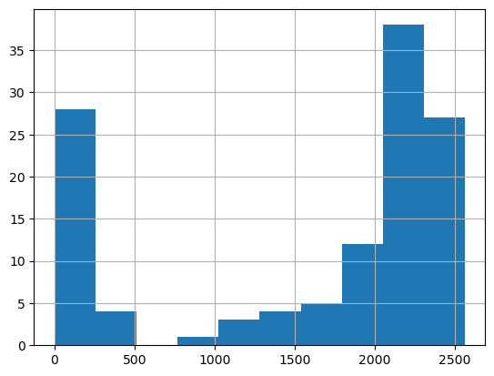

```python
zero_counts.hist()
```

```python
# Total Black Female pop. in Alternative Schooling
total_bf_enrollment = target_df['SCH_ENR_BL_F'].sum()
print(f"Total Black female student population in Alternative Schooling: {int(total_bf_enrollment)}")
```

```
Total Black female student population in Alternative Schooling: 30728
```

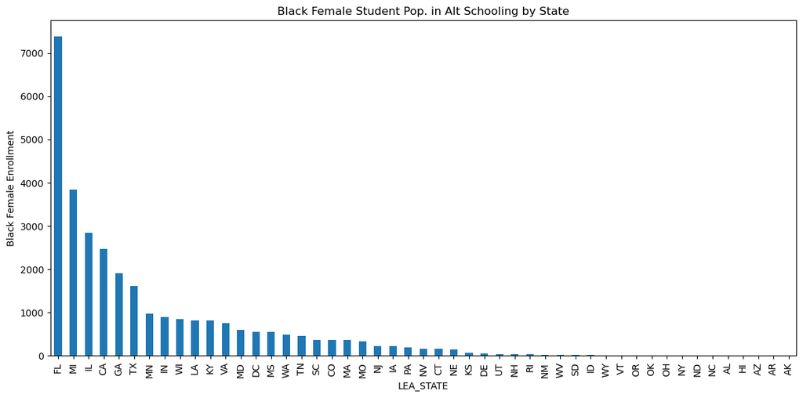

```python
bf_by_state = target_df.groupby('LEA_STATE')['SCH_ENR_BL_F'].sum().sort_values(ascending=False)
bf_by_state = bf_by_state.reset_index()
bf_by_state.columns = ['LEA_STATE', 'total_bf_enrollment']


import matplotlib.pyplot as plt

bf_by_state.set_index('LEA_STATE').plot(kind='bar', figsize=(12, 6), legend=False)
plt.ylabel('Black Female Enrollment')
plt.title('Black Female Student Pop. in Alt Schooling by State')
plt.tight_layout()
plt.show()
```

## II. Retrieving Feature Variables: School-Provided Opportunity and Structure

```python
bf_variable_list
```

```
['LEA_HSEPART_BL_F',
 'LEA_DISTEDENR_BL_F',
 'SCH_MATHENR_ADVM_BL_F',
 'SCH_APENR_BL_F',
 'SCH_APMATHENR_BL_F',
 'SCH_APSCIENR_BL_F',
 'SCH_APOTHENR_BL_F',
 'SCH_APEXAM_ONEORMORE_BL_F',
 'SCH_APEXAM_NONE_BL_F',
 'SCH_ALGENR_G08_BL_F',
 'SCH_ALGENR_GS0910_BL_F',
 'SCH_ALGENR_GS1112_BL_F',
 'SCH_ALGPASS_G08_BL_F',
 'SCH_ALGPASS_GS0910_BL_F',
 'SCH_ALGPASS_GS1112_BL_F',
 'SCH_MATHENR_ALG2_BL_F',
 'SCH_SCIENR_BIOL_BL_F',
 'SCH_MATHENR_CALC_BL_F',
 'SCH_SCIENR_CHEM_BL_F',
 'SCH_PSDISC_CORP_BL_F',
 'SCH_DISCWODIS_CORP_BL_F',
 'SCH_DISCWDIS_CORP_IDEA_BL_F',
 'SCH_DUALENR_BL_F',
 'SCH_PSENR_BL_F',
 'SCH_ENR_BL_F',
 'SCH_LEPENR_BL_F',
 'SCH_LEPPROGENR_BL_F',
 'SCH_IDEAENR_BL_F',
 'SCH_504ENR_BL_F',
 'SCH_PSDISC_EXP_BL_F',
 'SCH_DISCWODIS_EXPWE_BL_F',
 'SCH_DISCWODIS_EXPWOE_BL_F',
 'SCH_DISCWODIS_EXPZT_BL_F',
 'SCH_DISCWDIS_EXPWE_IDEA_BL_F',
 'SCH_DISCWDIS_EXPWOE_IDEA_BL_F',
 'SCH_DISCWDIS_EXPZT_IDEA_BL_F',
 'SCH_MATHENR_GEOM_BL_F',
 'SCH_GTENR_BL_F',
 'SCH_HBREPORTED_SEX_BL_F',
 'SCH_HBREPORTED_RAC_BL_F',
```

[output cut: 20 more lines]

```
 'SCH_RET_G10_BL_F',
 'SCH_RET_G11_BL_F',
 'SCH_RET_G12_BL_F',
 'SCH_SATACT_BL_F',
 'SCH_PSDISC_SINGOOS_BL_F',
 'SCH_PSDISC_MULTOOS_BL_F',
 'SCH_DISCWODIS_ISS_BL_F',
 'SCH_DISCWODIS_SINGOOS_BL_F',
 'SCH_DISCWODIS_MULTOOS_BL_F',
 'SCH_DISCWDIS_ISS_IDEA_BL_F',
 'SCH_DISCWDIS_SINGOOS_IDEA_BL_F',
 'SCH_DISCWDIS_MULTOOS_IDEA_BL_F',
 'SCH_DAYSMISSED_BL_F',
 'SCH_DISCWODIS_TFRALT_BL_F',
 'SCH_DISCWDIS_TFRALT_IDEA_BL_F']
```

```python
# Get differences in variables in bf_variable_list but not in merged_full
remaining_bf_vars = list(set(bf_variable_list) - set(target_df.columns))
remaining_bf_vars
```

```
['SCH_RET_G02_BL_F',
 'SCH_SCIENR_PHYS_BL_F',
 'SCH_SCIENR_BIOL_BL_F',
 'SCH_ALGENR_G08_BL_F',
 'SCH_RET_G01_BL_F',
 'LEA_DISTEDENR_BL_F',
 'SCH_DISCWODIS_TFRALT_BL_F',
 'SCH_APMATHENR_BL_F',
 'SCH_APOTHENR_BL_F',
 'SCH_APEXAM_ONEORMORE_BL_F',
 'SCH_MATHENR_CALC_BL_F',
 'SCH_GTENR_BL_F',
 'SCH_ALGPASS_GS1112_BL_F',
 'SCH_LEPPROGENR_BL_F',
 'SCH_LEPENR_BL_F',
 'SCH_PSDISC_SINGOOS_BL_F',
 'SCH_RET_KG_BL_F',
 'SCH_ALGENR_GS0910_BL_F',
 'SCH_PSDISC_EXP_BL_F',
 'SCH_PSDISC_CORP_BL_F',
 'SCH_PSENR_BL_F',
 'SCH_RET_G05_BL_F',
 'SCH_IBENR_BL_F',
 'SCH_PSDISC_MULTOOS_BL_F',
 'SCH_ALGENR_GS1112_BL_F',
 'LEA_HSEPART_BL_F',
 'SCH_SCIENR_CHEM_BL_F',
 'SCH_MATHENR_ALG2_BL_F',
 'SCH_MATHENR_ADVM_BL_F',
 'SCH_DUALENR_BL_F',
 'SCH_SATACT_BL_F',
 'SCH_DISCWDIS_TFRALT_IDEA_BL_F',
 'SCH_MATHENR_GEOM_BL_F',
 'SCH_RET_G03_BL_F',
 'SCH_APEXAM_NONE_BL_F',
 'SCH_RET_G04_BL_F',
 'SCH_ALGPASS_GS0910_BL_F',
 'SCH_APENR_BL_F',
 'SCH_ALGPASS_G08_BL_F',
 'SCH_APSCIENR_BL_F']
```

### 1. Getting Remainder of BL_F Variables

- stored in remaining_bf_vars

```python
# Need enrollment for both dataframes
enrollment_vars = [
'SCH_ENR_BL_F',
'SCH_IDEAENR_BL_F',
'SCH_504ENR_BL_F',
'TOT_ENR_M',
'TOT_ENR_F',
'COMBOKEY'
]

enrollment_df = pd.read_csv("/Users/joyamelvin/Desktop/Data_Science_II/Last_Girls_Standing_Repo/2017-18_CRDC_data/2017-18 Public-Use Files/Data/SCH/CRDC/CSV/Enrollment.csv",
    usecols=enrollment_vars,
    encoding='latin1'  # safer encoding
)

# Advanced Mathematics
advanced_math_vars = [
 'SCH_MATHENR_ADVM_BL_F',
 'COMBOKEY'
]

# Load just the columns you need
advanced_math_df = pd.read_csv(
    "/Users/joyamelvin/Desktop/Data_Science_II/Last_Girls_Standing_Repo/2017-18_CRDC_data/2017-18 Public-Use Files/Data/SCH/CRDC/CSV/Advanced Mathematics.csv",
    usecols=advanced_math_vars,
    encoding='latin1'  # safer encoding
)

# Dual Enrollment Programs
dual_enrollment_vars = [
    'SCH_DUALENR_BL_F',
    'SCH_DUAL_IND',
    'COMBOKEY'
]
# Load just the columns you need
dual_enrollment_df = pd.read_csv(
    "/Users/joyamelvin/Desktop/Data_Science_II/Last_Girls_Standing_Repo/2017-18_CRDC_data/2017-18 Public-Use Files/Data/SCH/CRDC/CSV/Dual Enrollment.csv",
    usecols=dual_enrollment_vars,
    encoding='latin1'  # safer encoding
)

# Gifted and Talented
gifted_enrollment_vars = [
    'SCH_GTENR_BL_F',
    'SCH_GT_IND',
    'COMBOKEY'
]
# Load just the columns you need
gifted_enrollment_df = pd.read_csv(
    "/Users/joyamelvin/Desktop/Data_Science_II/Last_Girls_Standing_Repo/2017-18_CRDC_data/2017-18 Public-Use Files/Data/SCH/CRDC/CSV/Gifted and Talented.csv",
    usecols=gifted_enrollment_vars,
    encoding='latin1'  # safer encoding
)

# International Baccaleaurate
ib_program_vars = [
    'SCH_IBENR_BL_F',
    'SCH_IBENR_IND',
    'COMBOKEY'
]
# Load just the columns you need
ib_program_df = pd.read_csv(
    "/Users/joyamelvin/Desktop/Data_Science_II/Last_Girls_Standing_Repo/2017-18_CRDC_data/2017-18 Public-Use Files/Data/SCH/CRDC/CSV/International Baccalaureate.csv",
    usecols=ib_program_vars,
    encoding='latin1'  # safer encoding
)

# ACT Test Participation
act_vars = [
    'SCH_SATACT_BL_F',
    'COMBOKEY'
]
# Load just the columns you need
act_vars_df = pd.read_csv(
    "/Users/joyamelvin/Desktop/Data_Science_II/Last_Girls_Standing_Repo/2017-18_CRDC_data/2017-18 Public-Use Files/Data/SCH/CRDC/CSV/SAT and ACT.csv",
    usecols=act_vars,
    encoding='latin1'  # safer encoding
)
```

### 2. School-Safety Indicators

- Highly violent or low violent environment?

```python
# Offense Variables
offense_vars = [
    'SCH_OFFENSE_RAPE',
    'SCH_OFFENSE_BATT',
    'SCH_OFFENSE_ROBWW',
    'SCH_OFFENSE_ROBWX',
    'SCH_OFFENSE_ROBWOW',
    'SCH_OFFENSE_ATTWW',
    'SCH_OFFENSE_ATTWX',
    'SCH_OFFENSE_ATTWOW',
    'SCH_OFFENSE_THRWW',
    'SCH_OFFENSE_THRWX',
    'SCH_OFFENSE_THRWOW',
    'SCH_OFFENSE_POSSWX',
    'COMBOKEY'
]
# Load just the columns you need
offense_df = pd.read_csv(
    "/Users/joyamelvin/Desktop/Data_Science_II/Last_Girls_Standing_Repo/2017-18_CRDC_data/2017-18 Public-Use Files/Data/SCH/CRDC/CSV/Offenses.csv",
    usecols=offense_vars,
    encoding='latin1'  # safer encoding
)
```

### 3. Funding Allocation Variables

```python
# Total Resource Allocation: capture overall personnel investment SCH_SAL_TEACH_WFED SCH_SAL_SUP_WFED SCH_SAL_ADM_WFED SCH_NPE_WFED
salary_vars = [
    'SCH_SAL_TOTPERS_WFED', # Salary expenditure for Total Personnel (funded by the gov.)
    'SCH_SAL_TEACH_WFED', # Salary expenditure for Teachers (funded by the gov.)
    'SCH_SAL_ADM_WFED', # Salary expenditure for Administrators (funded by the gov.)
    'SCH_SAL_SUP_WFED', # Salary expenditure for all Support Services staff (funded by the gov.)
    'COMBOKEY'
]
# Load just the columns you need
salary_df = pd.read_csv(
    "/Users/joyamelvin/Desktop/Data_Science_II/Last_Girls_Standing_Repo/2017-18_CRDC_data/2017-18 Public-Use Files/Data/SCH/CRDC/CSV/School Expenditures.csv",
    usecols=salary_vars,
    encoding='latin1'  # safer encoding
)
```

### 4. School Support

```python
# School Support
teachers_vars = [
    'SCH_FTECOUNSELORS', # of counselors
    'SCH_FTESERVICES_SOC', # of social workers
    'SCH_FTESERVICES_PSY', # of psychologists
    'SCH_FTESERVICES_NUR', # of nurses
    'SCH_FTESECURITY_LEO', # of law enforcement officers
    'SCH_FTESECURITY_GUA', # of security guards d
    'SCH_FTETEACH_TOT', #total teachers
    'SCH_FTETEACH_NOTCERT', #teachers not certified
    'COMBOKEY'
]
# Load just the columns you need
teachers_df = pd.read_csv(
    "/Users/joyamelvin/Desktop/Data_Science_II/Last_Girls_Standing_Repo/2017-18_CRDC_data/2017-18 Public-Use Files/Data/SCH/CRDC/CSV/School Support.csv",
    usecols=teachers_vars,
    encoding='latin1'  # safer encoding
)
```

```python
# Merge
feature_df = school_filtered.copy()

for df in [
    enrollment_df,
    advanced_math_df,
    dual_enrollment_df,
    gifted_enrollment_df,
    ib_program_df,
    act_vars_df,
    offense_df,
    salary_df,
    teachers_df
]:
    feature_df = pd.merge(feature_df, df, on='COMBOKEY', how='left')
```

```python
feature_df.info()
```

```
<class 'pandas.core.frame.DataFrame'>
RangeIndex: 3343 entries, 0 to 3342
Data columns (total 44 columns):
 #   Column                 Non-Null Count  Dtype
---  ------                 --------------  -----
 0   LEA_STATE              3343 non-null   object
 1   LEAID                  3343 non-null   object
 2   SCH_ALTFOCUS           3343 non-null   object
 3   SCH_STATUS_ALT         3343 non-null   object
 4   SCHID                  3343 non-null   int64
 5   SCH_NAME               3343 non-null   object
 6   COMBOKEY               3343 non-null   object
 7   SCH_ENR_BL_F           2829 non-null   float64
 8   TOT_ENR_M              2829 non-null   float64
 9   TOT_ENR_F              2829 non-null   float64
```

[output cut: 36 more lines]

```python
# Data Limitations: Visualize Reserve Codes
# Reserve codes to drop
codes = [-3, -5, -6, -8, -9, -11]

reserve_counts = {}

for col in feature_df.columns:
    if pd.api.types.is_numeric_dtype(feature_df[col]):
        count = feature_df[col].isin(codes).sum()
    else:
        count = feature_df[col].isin([str(code) for code in codes]).sum()

    reserve_counts[col] = count

reserve_summary = pd.DataFrame.from_dict(reserve_counts, orient='index', columns=['Reserve Code Count'])
reserve_summary = reserve_summary[reserve_summary['Reserve Code Count'] > 0].sort_values(by='Reserve Code Count', ascending=False)

reserve_summary.head(40)
```

|  | Reserve Code Count |
| --- | --- |
| SCH_IBENR_BL_F | 2001 |
| SCH_DUALENR_BL_F | 1745 |
| SCH_MATHENR_ADVM_BL_F | 1701 |
| SCH_GTENR_BL_F | 1527 |
| SCH_IBENR_IND | 257 |
| SCH_DUAL_IND | 150 |
| SCH_SATACT_BL_F | 150 |
| SCH_FTESECURITY_GUA | 109 |
| SCH_OFFENSE_THRWW | 26 |
| SCH_OFFENSE_ROBWX | 25 |
| SCH_OFFENSE_ATTWX | 25 |
| SCH_OFFENSE_THRWX | 25 |
| SCH_OFFENSE_ATTWW | 24 |
| SCH_OFFENSE_RAPE | 24 |
| SCH_OFFENSE_THRWOW | 24 |
| SCH_OFFENSE_ROBWW | 24 |
| SCH_OFFENSE_BATT | 22 |
| SCH_OFFENSE_ROBWOW | 22 |
| SCH_OFFENSE_ATTWOW | 22 |
| SCH_OFFENSE_POSSWX | 14 |
| SCH_SAL_ADM_WFED | 10 |
| SCH_SAL_TOTPERS_WFED | 10 |
| SCH_SAL_TEACH_WFED | 10 |
| SCH_SAL_SUP_WFED | 10 |
| SCH_FTETEACH_TOT | 9 |
| SCH_FTETEACH_NOTCERT | 9 |
| SCH_FTECOUNSELORS | 9 |
| SCH_FTESECURITY_LEO | 9 |
| SCH_FTESERVICES_NUR | 9 |
| SCH_FTESERVICES_PSY | 9 |
| SCH_FTESERVICES_SOC | 9 |
| SCH_GT_IND | 1 |

```python
nine_codes = [-9]

reserve_counts = {}

for col in feature_df.columns:
    if pd.api.types.is_numeric_dtype(feature_df[col]):
        count = feature_df[col].isin(codes).sum()
    else:
        count = feature_df[col].isin([str(code) for code in codes]).sum()

    reserve_counts[col] = count

reserve_summary = pd.DataFrame.from_dict(reserve_counts, orient='index', columns=['Reserve Code Count'])
reserve_summary = reserve_summary[reserve_summary['Reserve Code Count'] > 0].sort_values(by='Reserve Code Count', ascending=False)

reserve_summary.head(40)
```

|  | Reserve Code Count |
| --- | --- |
| SCH_IBENR_BL_F | 2001 |
| SCH_DUALENR_BL_F | 1745 |
| SCH_MATHENR_ADVM_BL_F | 1701 |
| SCH_GTENR_BL_F | 1527 |
| SCH_IBENR_IND | 257 |
| SCH_DUAL_IND | 150 |
| SCH_SATACT_BL_F | 150 |
| SCH_FTESECURITY_GUA | 109 |
| SCH_OFFENSE_THRWW | 26 |
| SCH_OFFENSE_ROBWX | 25 |
| SCH_OFFENSE_ATTWX | 25 |
| SCH_OFFENSE_THRWX | 25 |
| SCH_OFFENSE_ATTWW | 24 |
| SCH_OFFENSE_RAPE | 24 |
| SCH_OFFENSE_THRWOW | 24 |
| SCH_OFFENSE_ROBWW | 24 |
| SCH_OFFENSE_BATT | 22 |
| SCH_OFFENSE_ROBWOW | 22 |
| SCH_OFFENSE_ATTWOW | 22 |
| SCH_OFFENSE_POSSWX | 14 |
| SCH_SAL_ADM_WFED | 10 |
| SCH_SAL_TOTPERS_WFED | 10 |
| SCH_SAL_TEACH_WFED | 10 |
| SCH_SAL_SUP_WFED | 10 |
| SCH_FTETEACH_TOT | 9 |
| SCH_FTETEACH_NOTCERT | 9 |
| SCH_FTECOUNSELORS | 9 |
| SCH_FTESECURITY_LEO | 9 |
| SCH_FTESERVICES_NUR | 9 |
| SCH_FTESERVICES_PSY | 9 |
| SCH_FTESERVICES_SOC | 9 |
| SCH_GT_IND | 1 |

```python
# Visualize
reserve_codes = [-3, -5, -6, -8, -9, -11]

# Initialize dictionary to hold totals per code
code_totals = {code: 0 for code in reserve_codes}

for col in feature_df.columns:
    try:
        col_numeric = pd.to_numeric(feature_df[col], errors='coerce')
        for code in reserve_codes:
            code_totals[code] += (col_numeric == code).sum()
    except:
        continue  # skip columns that can't be coerced to numeric


# Convert to DataFrame for plotting
code_df = pd.DataFrame.from_dict(code_totals, orient='index', columns=['Count']).sort_values(by='Count', ascending=False)

# Plot
figsize = (8, 5)
fig1, ax1 = plt.subplots(figsize=figsize)
code_df.plot(kind='bar', legend=False, rot=0, color='orange', ax=ax1)
ax1.set_title('Reserve Codes for Feature Indicators (School-Provided Opportunity / Structure)')
ax1.set_xlabel('Reserve Code')
ax1.set_ylabel('Total Count')
ax1.grid(axis='y', linestyle='--', alpha=0.7)
plt.tight_layout()
plt.savefig('feature_reserve_code_distribution.png', dpi=300, bbox_inches='tight')
plt.close()
```

```python
# Dropping all reserve codes to get full dataset
# Reserve codes to drop
codes = [-3, -5, -6, -8, -9, -11]

# Columns to exclude
excluded_cols = ['LEA_STATE', 'LEAID', 'SCH_ALTFOCUS', 'SCH_STATUS_ALT', 'SCHID', 'SCH_NAME', 'COMBOKEY']

# Apply masking to all other columns
feature_df.loc[:, ~feature_df.columns.isin(excluded_cols)] = feature_df.loc[:, ~feature_df.columns.isin(excluded_cols)].apply(
    lambda col: col.mask(col.isin(codes)) if pd.api.types.is_numeric_dtype(col) else col.replace([str(code) for code in codes], np.nan)
)
```

```python
feature_df.info()
```

```
<class 'pandas.core.frame.DataFrame'>
RangeIndex: 3343 entries, 0 to 3342
Data columns (total 44 columns):
 #   Column                 Non-Null Count  Dtype
---  ------                 --------------  -----
 0   LEA_STATE              3343 non-null   object
 1   LEAID                  3343 non-null   object
 2   SCH_ALTFOCUS           3343 non-null   object
 3   SCH_STATUS_ALT         3343 non-null   object
 4   SCHID                  3343 non-null   int64
 5   SCH_NAME               3343 non-null   object
 6   COMBOKEY               3343 non-null   object
 7   SCH_ENR_BL_F           2829 non-null   float64
 8   TOT_ENR_M              2829 non-null   float64
 9   TOT_ENR_F              2829 non-null   float64
```

[output cut: 36 more lines]

## II. Preprocessing Data

```
a. Data Cleaning / Aggregation
b. Feature Engineering
c. Encode
d. Imputation
e. PCA (possible)
```

### a. Data Cleaning / Aggregation

```python
target_df.info()
```

```
<class 'pandas.core.frame.DataFrame'>
RangeIndex: 3343 entries, 0 to 3342
Columns: 122 entries, LEA_STATE to SCH_504ENR_BL_F
dtypes: float64(115), int64(1), object(6)
memory usage: 3.1+ MB
```

```python
feature_df.info()
```

```
<class 'pandas.core.frame.DataFrame'>
RangeIndex: 3343 entries, 0 to 3342
Data columns (total 44 columns):
 #   Column                 Non-Null Count  Dtype
---  ------                 --------------  -----
 0   LEA_STATE              3343 non-null   object
 1   LEAID                  3343 non-null   object
 2   SCH_ALTFOCUS           3343 non-null   object
 3   SCH_STATUS_ALT         3343 non-null   object
 4   SCHID                  3343 non-null   int64
 5   SCH_NAME               3343 non-null   object
 6   COMBOKEY               3343 non-null   object
 7   SCH_ENR_BL_F           2829 non-null   float64
 8   TOT_ENR_M              2829 non-null   float64
 9   TOT_ENR_F              2829 non-null   float64
```

[output cut: 36 more lines]

#### Checking missing values

target_df

- More than 95% : Drop Corporal Punishment etc.; not useful
- 60% - 95% : Aggregate into "total retention"
- 25% - 50%: Mostly Arrests, suspensions, restraint, referrals, harassment, expulsion; Impute missing values as 0; likely never happened or undocumented.
- < 25% : Impute the rest as 0
- Drop rows empty or 0 for enrollment (does not have black girls in their school)

```python
missing_target_data = pd.DataFrame({
    'Missing': target_df.isnull().sum(),
    'Present': target_df.notnull().sum(),
    'Total': target_df.shape[0]
})
missing_target_data['% Missing'] = (missing_target_data['Missing'] / missing_target_data['Total']) * 100
missing_target_data
```

|  | Missing | Present | Total | % Missing |
| --- | --- | --- | --- | --- |
| LEA_STATE | 0 | 3343 | 3343 | 0.000000 |
| LEAID | 0 | 3343 | 3343 | 0.000000 |
| SCH_ALTFOCUS | 0 | 3343 | 3343 | 0.000000 |
| SCH_STATUS_ALT | 0 | 3343 | 3343 | 0.000000 |
| SCHID | 0 | 3343 | 3343 | 0.000000 |
| ... | ... | ... | ... | ... |
| SCH_ENR_BL_F | 514 | 2829 | 3343 | 15.375411 |
| TOT_ENR_M | 514 | 2829 | 3343 | 15.375411 |
| TOT_ENR_F | 514 | 2829 | 3343 | 15.375411 |
| SCH_IDEAENR_BL_F | 514 | 2829 | 3343 | 15.375411 |
| SCH_504ENR_BL_F | 514 | 2829 | 3343 | 15.375411 |

122 rows × 4 columns

```python
# saving to spotcheck
target_df.to_csv('/Users/joyamelvin/Desktop/Data_Science_II/Final_Project/raw_data/target_df_draft.csv')
```

```python
missing_feature_data = pd.DataFrame({
    'Missing': feature_df.isnull().sum(),
    'Present': feature_df.notnull().sum(),
    'Total': feature_df.shape[0]
})
missing_feature_data['% Missing'] = (missing_feature_data['Missing'] / missing_feature_data['Total']) * 100
missing_feature_data
```

|  | Missing | Present | Total | % Missing |
| --- | --- | --- | --- | --- |
| LEA_STATE | 0 | 3343 | 3343 | 0.000000 |
| LEAID | 0 | 3343 | 3343 | 0.000000 |
| SCH_ALTFOCUS | 0 | 3343 | 3343 | 0.000000 |
| SCH_STATUS_ALT | 0 | 3343 | 3343 | 0.000000 |
| SCHID | 0 | 3343 | 3343 | 0.000000 |
| SCH_NAME | 0 | 3343 | 3343 | 0.000000 |
| COMBOKEY | 0 | 3343 | 3343 | 0.000000 |
| SCH_ENR_BL_F | 514 | 2829 | 3343 | 15.375411 |
| TOT_ENR_M | 514 | 2829 | 3343 | 15.375411 |
| TOT_ENR_F | 514 | 2829 | 3343 | 15.375411 |
| SCH_IDEAENR_BL_F | 514 | 2829 | 3343 | 15.375411 |
| SCH_504ENR_BL_F | 514 | 2829 | 3343 | 15.375411 |
| SCH_MATHENR_ADVM_BL_F | 3040 | 303 | 3343 | 90.936285 |
| SCH_DUAL_IND | 1489 | 1854 | 3343 | 44.540832 |
| SCH_DUALENR_BL_F | 3084 | 259 | 3343 | 92.252468 |
| SCH_GT_IND | 1340 | 2003 | 3343 | 40.083757 |
| SCH_GTENR_BL_F | 2866 | 477 | 3343 | 85.731379 |
| SCH_IBENR_IND | 1596 | 1747 | 3343 | 47.741550 |
| SCH_IBENR_BL_F | 3340 | 3 | 3343 | 99.910260 |
| SCH_SATACT_BL_F | 1489 | 1854 | 3343 | 44.540832 |
| SCH_OFFENSE_RAPE | 1363 | 1980 | 3343 | 40.771762 |
| SCH_OFFENSE_BATT | 1361 | 1982 | 3343 | 40.711935 |
| SCH_OFFENSE_ROBWW | 1363 | 1980 | 3343 | 40.771762 |
| SCH_OFFENSE_ROBWX | 1364 | 1979 | 3343 | 40.801675 |
| SCH_OFFENSE_ROBWOW | 1361 | 1982 | 3343 | 40.711935 |
| SCH_OFFENSE_ATTWW | 1363 | 1980 | 3343 | 40.771762 |
| SCH_OFFENSE_ATTWX | 1364 | 1979 | 3343 | 40.801675 |
| SCH_OFFENSE_ATTWOW | 1361 | 1982 | 3343 | 40.711935 |
| SCH_OFFENSE_THRWW | 1365 | 1978 | 3343 | 40.831588 |
| SCH_OFFENSE_THRWX | 1364 | 1979 | 3343 | 40.801675 |
| SCH_OFFENSE_THRWOW | 1363 | 1980 | 3343 | 40.771762 |
| SCH_OFFENSE_POSSWX | 1353 | 1990 | 3343 | 40.472629 |
| SCH_SAL_TEACH_WFED | 1349 | 1994 | 3343 | 40.352976 |
| SCH_SAL_SUP_WFED | 1349 | 1994 | 3343 | 40.352976 |
| SCH_SAL_ADM_WFED | 1349 | 1994 | 3343 | 40.352976 |
| SCH_SAL_TOTPERS_WFED | 1349 | 1994 | 3343 | 40.352976 |
| SCH_FTETEACH_TOT | 1348 | 1995 | 3343 | 40.323063 |
| SCH_FTETEACH_NOTCERT | 1348 | 1995 | 3343 | 40.323063 |
| SCH_FTECOUNSELORS | 1348 | 1995 | 3343 | 40.323063 |
| SCH_FTESECURITY_LEO | 1348 | 1995 | 3343 | 40.323063 |
| SCH_FTESECURITY_GUA | 1448 | 1895 | 3343 | 43.314388 |
| SCH_FTESERVICES_NUR | 1348 | 1995 | 3343 | 40.323063 |
| SCH_FTESERVICES_PSY | 1348 | 1995 | 3343 | 40.323063 |
| SCH_FTESERVICES_SOC | 1348 | 1995 | 3343 | 40.323063 |

```python
target_df.SCH_ENR_BL_F.describe()
```

```
count    2829.000000
mean       10.861789
std        27.755149
min         0.000000
25%         0.000000
50%         1.000000
75%         9.000000
max       430.000000
Name: SCH_ENR_BL_F, dtype: float64
```

### b. Feature Engineering

target_df

- More than 95% : Drop Corporal Punishment etc.; not useful
- 60% - 95% : Aggregate into "total retention"; make a binary class
- 25% - 50%: Mostly Arrests, suspensions, restraint, referrals, harassment, expulsion; Impute missing values as 0; likely never happened or undocumented.
- < 25% : Impute the rest as 0
- Drop rows empty or 0 for enrollment (does not have black girls in their school)

#### target_df Enrollment - Drop 0's and Missing

```python
# Calculate total population in target_df
total_population = ['TOT_ENR_M', 'TOT_ENR_F']
target_df['total_population'] = target_df[total_population].sum(axis=1, skipna=True)
target_df.drop(columns=total_population, inplace=True)

# Merge total_population into feature_df using COMBOKEY
feature_df = feature_df.merge(
    target_df[['COMBOKEY', 'total_population']],
    on='COMBOKEY',
    how='left'
)
```

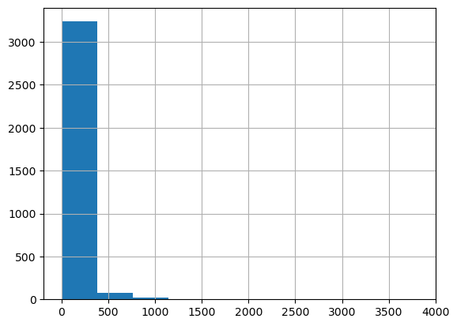

```python
target_df.total_population.hist()
```

```python
target_df = target_df[target_df['SCH_ENR_BL_F'].notna() & (target_df['SCH_ENR_BL_F'] > 0)]
```

```python
target_df.info()
```

```
<class 'pandas.core.frame.DataFrame'>
Index: 1748 entries, 319 to 3342
Columns: 121 entries, LEA_STATE to total_population
dtypes: float64(114), int64(1), object(6)
memory usage: 1.6+ MB
```

#### target_df Retention Indicator - Aggregation

```python
# Sum total retention across grades 6-12
total_retention_mid_high = [
    'TOT_RET_G06_M',
    'TOT_RET_G06_F',
    'TOT_RET_G07_M',
    'TOT_RET_G07_F',
    'TOT_RET_G08_M',
    'TOT_RET_G08_F',
    'TOT_RET_G09_M',
    'TOT_RET_G09_F',
    'TOT_RET_G10_M',
    'TOT_RET_G10_F',
    'TOT_RET_G11_M',
    'TOT_RET_G11_F',
    'TOT_RET_G12_M',
    'TOT_RET_G12_F'
]

target_df['total_retention_mid_high'] = target_df[total_retention_mid_high].sum(axis=1, skipna=True)
target_df.drop(columns=total_retention_mid_high, inplace=True)


# Aggregating all bf retention rates
bf_total_retention_mid_high = [
    'SCH_RET_G06_BL_F', 'SCH_RET_G07_BL_F', 'SCH_RET_G08_BL_F',
    'SCH_RET_G09_BL_F', 'SCH_RET_G10_BL_F', 'SCH_RET_G11_BL_F', 'SCH_RET_G12_BL_F'
]
target_df['bf_total_retention_mid_high'] = target_df[bf_total_retention_mid_high].sum(axis=1, skipna=True)
target_df.drop(columns=bf_total_retention_mid_high, inplace=True)


# --- Step 3: Calculate the proportion of retention that is Black girls ---
target_df['bf_retention_percentage'] = target_df['bf_total_retention_mid_high'] / target_df['total_retention_mid_high']

# --- Step 4: Handle divide-by-zero and NaNs ---
target_df['bf_retention_percentage'] = target_df['bf_retention_percentage'].replace([np.inf, -np.inf], np.nan).fillna(0)


# Normalize by total bf enrolled (out of how many black girles enrolled did each school retain)?
#target_df['retention_rate_bf'] = target_df['bf_total_retention_mid_high'] / target_df['SCH_ENR_BL_F']
#target_df['retention_rate_bf'] = target_df['retention_rate_bf'].replace([np.inf, -np.inf], np.nan).fillna(0)

# Create threshold
target_df['bf_retention_binary'] = (target_df['bf_retention_percentage'] > 0.25).astype(int)
target_df['bf_retention_binary'].value_counts()

# So there are 147 alternative schools who have more than 25% of retained students being black girls.
```

```
bf_retention_binary
0    1601
1     147
Name: count, dtype: int64
```

```python
# Which threshold? 10% or 25%
# Choosing 10% because even small disparities matter. In 345 alternative schools, 1 out of the 10 students retained are black girls.
target_df['bf_retention_binary'] = (target_df['bf_retention_percentage'] > 0.10).astype(int)
target_df['bf_retention_binary'].value_counts()
```

```
bf_retention_binary
0    1403
1     345
Name: count, dtype: int64
```

#### target_df Harm columns

- Drop >95% missing
- Impute harm event accounts (I want to account the 0's meaning that there is no harm)
- Normalize
- Binarize with 10% threshold

```python
missing_target_data = pd.DataFrame({
    'Missing': target_df.isnull().sum(),
    'Present': target_df.notnull().sum(),
    'Total': target_df.shape[0]
})
missing_target_data['% Missing'] = (missing_target_data['Missing'] / missing_target_data['Total']) * 100
missing_target_data
```

|  | Missing | Present | Total | % Missing |
| --- | --- | --- | --- | --- |
| LEA_STATE | 0 | 1748 | 1748 | 0.0 |
| LEAID | 0 | 1748 | 1748 | 0.0 |
| SCH_ALTFOCUS | 0 | 1748 | 1748 | 0.0 |
| SCH_STATUS_ALT | 0 | 1748 | 1748 | 0.0 |
| SCHID | 0 | 1748 | 1748 | 0.0 |
| ... | ... | ... | ... | ... |
| total_population | 0 | 1748 | 1748 | 0.0 |
| total_retention_mid_high | 0 | 1748 | 1748 | 0.0 |
| bf_total_retention_mid_high | 0 | 1748 | 1748 | 0.0 |
| bf_retention_percentage | 0 | 1748 | 1748 | 0.0 |
| bf_retention_binary | 0 | 1748 | 1748 | 0.0 |

104 rows × 4 columns

```python
# Out of all black girls in alternative schools: 47 black girls wo disability received corporal punishment. DROP.
# Out of all black girls in alternative schools: 3 black girls w disability received corporal punishment. DROP.
# SCH_PSDISC_EXP_BL_F - preschool expulsion = 0 (not in sample). DROP

threshold = 0.90  # 90% missing
missing_ratios = target_df.isnull().mean()
cols_to_drop_auto = missing_ratios[missing_ratios > threshold].index.tolist()

target_df.drop(columns=cols_to_drop_auto, inplace=True)
```

```python
# Imputing 0's for missing values : Should I impute here?
# Rationale: I have already eradicated reserve codes, which identified Not/Applicable and Skipped answers in the surveys,
# narrowing the data in that aspect.
# In accounting for reserve codes and with under 20% of missing values for harm columns, we are assuming that these incidents did not affect black girls
# by imputing 0's. Either these incidents are underreported for black girls (which may be the case), but I would rather not infer that be the answer by
# imputing values for harm on black girls and increasing bias on my part. Rather it be bias on the data collection and/or school for underreporting
# incidents affecting black girls, than me "creating" a problem.
harm_event_cols = [
    'SCH_DISCWODIS_EXPWE_BL_F', 'SCH_DISCWODIS_EXPWOE_BL_F',
    'SCH_DISCWODIS_EXPZT_BL_F', 'SCH_DISCWDIS_EXPWE_IDEA_BL_F', 'SCH_DISCWDIS_EXPWOE_IDEA_BL_F',
    'SCH_DISCWDIS_EXPZT_IDEA_BL_F', 'SCH_HBREPORTED_SEX_BL_F', 'SCH_HBREPORTED_RAC_BL_F',
    'SCH_HBREPORTED_DIS_BL_F', 'SCH_HBDISCIPLINED_SEX_BL_F', 'SCH_HBDISCIPLINED_RAC_BL_F',
    'SCH_HBDISCIPLINED_DIS_BL_F', 'SCH_DISCWODIS_REF_BL_F', 'SCH_DISCWDIS_REF_IDEA_BL_F',
    'SCH_DISCWODIS_ARR_BL_F', 'SCH_DISCWDIS_ARR_IDEA_BL_F', 'SCH_RS_NONIDEA_MECH_BL_F',
    'SCH_RS_NONIDEA_PHYS_BL_F', 'SCH_RS_NONIDEA_SECL_BL_F', 'SCH_RS_IDEA_MECH_BL_F',
    'SCH_RS_IDEA_PHYS_BL_F', 'SCH_RS_IDEA_SECL_BL_F', 'SCH_DISCWODIS_ISS_BL_F',
    'SCH_DISCWODIS_SINGOOS_BL_F', 'SCH_DISCWODIS_MULTOOS_BL_F', 'SCH_DISCWDIS_ISS_IDEA_BL_F',
    'SCH_DISCWDIS_SINGOOS_IDEA_BL_F', 'SCH_DISCWDIS_MULTOOS_IDEA_BL_F', 'SCH_DAYSMISSED_BL_F',
    'TOT_DISCWODIS_REF_M', 'TOT_DISCWODIS_REF_F', 'TOT_DISCWDIS_REF_IDEA_M', 'TOT_DISCWDIS_REF_IDEA_F',
    'TOT_RS_NONIDEA_MECH_M', 'TOT_RS_NONIDEA_MECH_F', 'TOT_RS_NONIDEA_PHYS_M', 'TOT_RS_NONIDEA_PHYS_F',
    'TOT_RS_NONIDEA_SECL_M', 'TOT_RS_NONIDEA_SECL_F', 'TOT_RS_IDEA_MECH_M', 'TOT_RS_IDEA_MECH_F',
    'TOT_RS_IDEA_PHYS_M', 'TOT_RS_IDEA_PHYS_F', 'TOT_RS_IDEA_SECL_M', 'TOT_RS_IDEA_SECL_F',
    'TOT_DISCWODIS_ISS_M', 'TOT_DISCWODIS_ISS_F', 'TOT_DISCWODIS_SINGOOS_M', 'TOT_DISCWODIS_SINGOOS_F',
    'TOT_DISCWODIS_MULTOOS_M', 'TOT_DISCWODIS_MULTOOS_F', 'TOT_DISCWDIS_ISS_IDEA_M', 'TOT_DISCWDIS_ISS_IDEA_F',
    'TOT_DISCWDIS_SINGOOS_IDEA_M', 'TOT_DISCWDIS_SINGOOS_IDEA_F', 'TOT_DISCWDIS_MULTOOS_IDEA_M', 'TOT_DISCWDIS_MULTOOS_IDEA_F',
    'TOT_DAYSMISSED_M', 'TOT_DAYSMISSED_F', 'TOT_HBREPORTED_SEX_M', 'TOT_HBREPORTED_SEX_F',
    'TOT_HBREPORTED_RAC_M', 'TOT_HBREPORTED_RAC_F', 'TOT_HBREPORTED_DIS_M', 'TOT_HBREPORTED_DIS_F',
    'TOT_HBDISCIPLINED_SEX_M', 'TOT_HBDISCIPLINED_SEX_F', 'TOT_HBDISCIPLINED_RAC_M', 'TOT_HBDISCIPLINED_RAC_F',
    'TOT_HBDISCIPLINED_DIS_M', 'TOT_HBDISCIPLINED_DIS_F',     'TOT_DISCWODIS_EXPWE_M', 'TOT_DISCWODIS_EXPWE_F',
    'TOT_DISCWODIS_EXPWOE_M', 'TOT_DISCWODIS_EXPWOE_F', 'TOT_DISCWODIS_EXPZT_M', 'TOT_DISCWODIS_EXPZT_F',
    'TOT_DISCWDIS_EXPWE_IDEA_M', 'TOT_DISCWDIS_EXPWE_IDEA_F','TOT_DISCWDIS_EXPWOE_IDEA_M', 'TOT_DISCWDIS_EXPWOE_IDEA_F',
    'TOT_DISCWDIS_EXPZT_IDEA_M', 'TOT_DISCWDIS_EXPZT_IDEA_F'
]

# Fill NA with 0 for all listed columns
target_df[harm_event_cols] = target_df[harm_event_cols].fillna(0)
```

```python
# Checking missing values; should all be 0
missing_target_data = pd.DataFrame({
    'Missing': target_df.isnull().sum(),
    'Present': target_df.notnull().sum(),
    'Total': target_df.shape[0]
})
missing_target_data['% Missing'] = (missing_target_data['Missing'] / missing_target_data['Total']) * 100
missing_target_data
```

|  | Missing | Present | Total | % Missing |
| --- | --- | --- | --- | --- |
| LEA_STATE | 0 | 1748 | 1748 | 0.0 |
| LEAID | 0 | 1748 | 1748 | 0.0 |
| SCH_ALTFOCUS | 0 | 1748 | 1748 | 0.0 |
| SCH_STATUS_ALT | 0 | 1748 | 1748 | 0.0 |
| SCHID | 0 | 1748 | 1748 | 0.0 |
| ... | ... | ... | ... | ... |
| total_population | 0 | 1748 | 1748 | 0.0 |
| total_retention_mid_high | 0 | 1748 | 1748 | 0.0 |
| bf_total_retention_mid_high | 0 | 1748 | 1748 | 0.0 |
| bf_retention_percentage | 0 | 1748 | 1748 | 0.0 |
| bf_retention_binary | 0 | 1748 | 1748 | 0.0 |

102 rows × 4 columns

```python
# Combine BF referral + arrest counts
bf_police_vars = [
    'SCH_DISCWODIS_REF_BL_F',      # Non-IDEA referrals
    'SCH_DISCWDIS_REF_IDEA_BL_F',  # IDEA referrals
    'SCH_DISCWODIS_ARR_BL_F',      # Non-IDEA arrests
    'SCH_DISCWDIS_ARR_IDEA_BL_F'   # IDEA arrests
]
target_df['bf_police_involvement'] = target_df[bf_police_vars].sum(axis=1, skipna=True)

# Combine total referrals + arrests (all students)
total_police_vars = [
    'TOT_DISCWODIS_REF_M', 'TOT_DISCWODIS_REF_F',
    'TOT_DISCWDIS_REF_IDEA_M', 'TOT_DISCWDIS_REF_IDEA_F',
    'TOT_DISCWODIS_ARR_M', 'TOT_DISCWODIS_ARR_F',
    'TOT_DISCWDIS_ARR_IDEA_M', 'TOT_DISCWDIS_ARR_IDEA_F'
]
target_df['total_police_involvement'] = target_df[total_police_vars].sum(axis=1, skipna=True)

# Calculate share and apply threshold
target_df['police_involvement_share'] = target_df['bf_police_involvement'] / target_df['total_police_involvement']
target_df['police_involvement_share'] = target_df['police_involvement_share'].replace([np.inf, -np.inf], np.nan).fillna(0)

#Create binary harm indicator (10% threshold)
target_df['police_involvement_binary'] = (target_df['police_involvement_share'] > 0.10).astype(int)
```

```python
target_df['police_involvement_binary'].value_counts()
```

```
police_involvement_binary
0    1546
1     202
Name: count, dtype: int64
```

```python
target_df.police_involvement_share.describe()
```

```
count    1748.000000
mean        0.043432
std         0.141157
min         0.000000
25%         0.000000
50%         0.000000
75%         0.000000
max         1.000000
Name: police_involvement_share, dtype: float64
```

```python
target_df.SCH_RS_IDEA_MECH_BL_F.sum()
```

```
0.0
```

```python
# --- 1. Combine Black girl restraint & seclusion counts ---
bf_restraint_vars = [
    'SCH_RS_NONIDEA_MECH_BL_F',
    'SCH_RS_NONIDEA_PHYS_BL_F',
    'SCH_RS_NONIDEA_SECL_BL_F',
    'SCH_RS_IDEA_PHYS_BL_F',
    'SCH_RS_IDEA_SECL_BL_F'
]
target_df['bf_restraint_seclusion'] = target_df[bf_restraint_vars].sum(axis=1, skipna=True)

# --- 2. Combine total student restraint & seclusion counts ---
total_restraint_vars = [
    'TOT_RS_NONIDEA_MECH_M', 'TOT_RS_NONIDEA_MECH_F',
    'TOT_RS_NONIDEA_PHYS_M', 'TOT_RS_NONIDEA_PHYS_F',
    'TOT_RS_NONIDEA_SECL_M', 'TOT_RS_NONIDEA_SECL_F',
    'TOT_RS_IDEA_PHYS_M', 'TOT_RS_IDEA_PHYS_F',
    'TOT_RS_IDEA_SECL_M', 'TOT_RS_IDEA_SECL_F'
]
target_df['total_restraint_seclusion'] = target_df[total_restraint_vars].sum(axis=1, skipna=True)

# --- 3. Calculate share and clean up ---
target_df['restraint_share'] = target_df['bf_restraint_seclusion'] / target_df['total_restraint_seclusion']
target_df['restraint_share'] = target_df['restraint_share'].replace([np.inf, -np.inf], np.nan).fillna(0)

# --- 4. Create binary harm indicator (10% threshold) ---
target_df['restraint_binary'] = (target_df['restraint_share'] > 0.10).astype(int)
target_df['restraint_binary'].value_counts()
```

```
restraint_binary
0    1704
1      44
Name: count, dtype: int64
```

```python
# Suspension Feature Engineering
bf_suspension_vars = [
    'SCH_DISCWODIS_ISS_BL_F',
    'SCH_DISCWODIS_SINGOOS_BL_F',
    'SCH_DISCWODIS_MULTOOS_BL_F',
    'SCH_DISCWDIS_ISS_IDEA_BL_F',
    'SCH_DISCWDIS_SINGOOS_IDEA_BL_F',
    'SCH_DISCWDIS_MULTOOS_IDEA_BL_F',
    'SCH_DAYSMISSED_BL_F'
]
target_df['bf_suspension'] = target_df[bf_suspension_vars].sum(axis=1, skipna=True)

# --- 2. Combine total student suspension counts ---
total_suspension_vars = [
    'TOT_DISCWODIS_ISS_M', 'TOT_DISCWODIS_ISS_F',
    'TOT_DISCWODIS_SINGOOS_M', 'TOT_DISCWODIS_SINGOOS_F',
    'TOT_DISCWODIS_MULTOOS_M', 'TOT_DISCWODIS_MULTOOS_F',
    'TOT_DISCWDIS_ISS_IDEA_M', 'TOT_DISCWDIS_ISS_IDEA_F',
    'TOT_DISCWDIS_SINGOOS_IDEA_M', 'TOT_DISCWDIS_SINGOOS_IDEA_F',
    'TOT_DISCWDIS_MULTOOS_IDEA_M', 'TOT_DISCWDIS_MULTOOS_IDEA_F',
    'TOT_DAYSMISSED_M', 'TOT_DAYSMISSED_F'
]
target_df['total_suspension'] = target_df[total_suspension_vars].sum(axis=1, skipna=True)

# --- 3. Calculate Black girl suspension share ---
target_df['suspension_share'] = target_df['bf_suspension'] / target_df['total_suspension']
target_df['suspension_share'] = target_df['suspension_share'].replace([np.inf, -np.inf], np.nan).fillna(0)

# --- 4. Create binary harm indicator (10% threshold) ---
target_df['suspension_binary'] = (target_df['suspension_share'] > 0.10).astype(int)
target_df['suspension_binary'].value_counts()
```

```
suspension_binary
0    1264
1     484
Name: count, dtype: int64
```

```python
# Harrassment and Bullying
bf_harassment_vars = [
    'SCH_HBREPORTED_SEX_BL_F',
    'SCH_HBREPORTED_RAC_BL_F',
    'SCH_HBREPORTED_DIS_BL_F',
    'SCH_HBDISCIPLINED_SEX_BL_F',
    'SCH_HBDISCIPLINED_RAC_BL_F',
    'SCH_HBDISCIPLINED_DIS_BL_F'
]
target_df['bf_harassment'] = target_df[bf_harassment_vars].sum(axis=1, skipna=True)

# --- 2. Combine total harassment/discipline counts for all students ---
total_harassment_vars = [
    'TOT_HBREPORTED_SEX_M', 'TOT_HBREPORTED_SEX_F',
    'TOT_HBREPORTED_RAC_M', 'TOT_HBREPORTED_RAC_F',
    'TOT_HBREPORTED_DIS_M', 'TOT_HBREPORTED_DIS_F',
    'TOT_HBDISCIPLINED_SEX_M', 'TOT_HBDISCIPLINED_SEX_F',
    'TOT_HBDISCIPLINED_RAC_M', 'TOT_HBDISCIPLINED_RAC_F',
    'TOT_HBDISCIPLINED_DIS_M', 'TOT_HBDISCIPLINED_DIS_F'
]
target_df['total_harassment'] = target_df[total_harassment_vars].sum(axis=1, skipna=True)

# --- 3. Calculate Black girl harassment share ---
target_df['harassment_share'] = target_df['bf_harassment'] / target_df['total_harassment']
target_df['harassment_share'] = target_df['harassment_share'].replace([np.inf, -np.inf], np.nan).fillna(0)

# --- 4. Create binary harm indicator (10% threshold) ---
target_df['harassment_binary'] = (target_df['harassment_share'] > 0.10).astype(int)
target_df['harassment_binary'].value_counts()
```

```
harassment_binary
0    1691
1      57
Name: count, dtype: int64
```

```python
# Expulsions
bf_expulsion_vars = [
    'SCH_DISCWODIS_EXPWE_BL_F',  # with education services
    'SCH_DISCWODIS_EXPWOE_BL_F', # without education services
    'SCH_DISCWODIS_EXPZT_BL_F',  # zero tolerance
    'SCH_DISCWDIS_EXPWE_IDEA_BL_F',
    'SCH_DISCWDIS_EXPWOE_IDEA_BL_F',
    'SCH_DISCWDIS_EXPZT_IDEA_BL_F'
]
target_df['bf_expulsion'] = target_df[bf_expulsion_vars].sum(axis=1, skipna=True)

# --- 2. Combine total expulsion counts for all students ---
total_expulsion_vars = [
    'TOT_DISCWODIS_EXPWE_M', 'TOT_DISCWODIS_EXPWE_F',
    'TOT_DISCWODIS_EXPWOE_M', 'TOT_DISCWODIS_EXPWOE_F',
    'TOT_DISCWODIS_EXPZT_M', 'TOT_DISCWODIS_EXPZT_F',
    'TOT_DISCWDIS_EXPWE_IDEA_M', 'TOT_DISCWDIS_EXPWE_IDEA_F',
    'TOT_DISCWDIS_EXPWOE_IDEA_M', 'TOT_DISCWDIS_EXPWOE_IDEA_F',
    'TOT_DISCWDIS_EXPZT_IDEA_M', 'TOT_DISCWDIS_EXPZT_IDEA_F'
]

target_df['total_expulsion'] = target_df[total_expulsion_vars].sum(axis=1, skipna=True)

# --- 3. Calculate share and clean up ---
target_df['expulsion_share'] = target_df['bf_expulsion'] / target_df['total_expulsion']
target_df['expulsion_share'] = target_df['expulsion_share'].replace([np.inf, -np.inf], np.nan).fillna(0)

# --- 4. Create binary harm indicator (10% threshold) ---
target_df['expulsion_binary'] = (target_df['expulsion_share'] > 0.10).astype(int)
target_df['expulsion_binary'].value_counts()
```

```
expulsion_binary
0    1653
1      95
Name: count, dtype: int64
```